# R Notebook

Data Information and Preparation: The following dataset was retrieved from Kaggle. It collected values of weather patterns for every single day throughout various cities. These weather patterns were also paired with an indicator variable: whether it rained or it did not. The objective of this project is to use these weather patterns as predictor variables and determine if there exists a best logistic regression. Some predictors were excluded for simplicity.

The data was in a .csv format, allowing easy upload to RStudio. However, there were many rows of data with null values and empty cases. I decided to drop these cases in order to feed the model with the most full data. The indicator variable for whether it will rain or not was in english with YES or NO. I had to factor this into 1s and 0s. In conclusion, I dropped the NA rows and transformed the indicator variable so that the procedures could understand it.

```r
library(readr)
weatherAUS <- read_csv(file="C:/Users/samee/Google Drive/College/STOR 455/R/Datasets/albury.csv")
final = weatherAUS[,c("MinTemp", "MaxTemp", "Rainfall", "WindGustSpeed", "WindSpeed9am", "Humidity9am", "Pressure9am", "Temp9am", "RainTomorrow")]
```

```r
final = final[complete.cases(final),] #Dropping all rows that have one or more NA values.
final$RainTomorrow = as.numeric(as.factor(final$RainTomorrow))-1
head(final)
```

| MinTemp | MaxTemp | Rainfall | WindGustSpeed | WindSpeed9am | Humidity9am | Pressure9am | Temp9am | RainTomorrow |
| --- | --- | --- | --- | --- | --- | --- | --- | --- |
| 13.4 | 22.9 | 0.6 | 44 | 20 | 71 | 1007.7 | 16.9 | 0 |
| 7.4 | 25.1 | 0.0 | 44 | 4 | 44 | 1010.6 | 17.2 | 0 |
| 12.9 | 25.7 | 0.0 | 46 | 19 | 38 | 1007.6 | 21.0 | 0 |
| 9.2 | 28.0 | 0.0 | 24 | 11 | 45 | 1017.6 | 18.1 | 0 |
| 17.5 | 32.3 | 1.0 | 41 | 7 | 82 | 1010.8 | 17.8 | 0 |
| 14.6 | 29.7 | 0.2 | 56 | 19 | 55 | 1009.2 | 20.6 | 0 |

```r
#Mod1 is when I choose the WindGustSpeed quantitative predictor. Below is a summary of the model.
#As for individual t-tests, the null hypothesis is that the coefficient is equal to 0 (no relationship for the specific predictor), while the alternate hypothesis is that the coefficient is not equal to 0 (suggesting that the predictor has a relationship). We can see that the predictor WindGustSpeed's p-value is 2e-16. Thus we reject the null hypothesis.
mod1 = glm(RainTomorrow ~ WindGustSpeed, family=binomial, data=final)
summary(mod1)
```

```
Call:
glm(formula = RainTomorrow ~ WindGustSpeed, family = binomial,
    data = final)

Deviance Residuals:
    Min       1Q   Median       3Q      Max
-1.5679  -0.6743  -0.5564  -0.4366   2.2670

Coefficients:
               Estimate Std. Error z value Pr(>|z|)
(Intercept)   -3.005183   0.135782  -22.13   <2e-16 ***
WindGustSpeed  0.046846   0.003436   13.63   <2e-16 ***
---
Signif. codes:  0 ‘***’ 0.001 ‘**’ 0.01 ‘*’ 0.05 ‘.’ 0.1 ‘ ’ 1

(Dispersion parameter for binomial family taken to be 1)

    Null deviance: 3019.4  on 2976  degrees of freedom
Residual deviance: 2819.9  on 2975  degrees of freedom
AIC: 2823.9

Number of Fisher Scoring iterations: 4
```

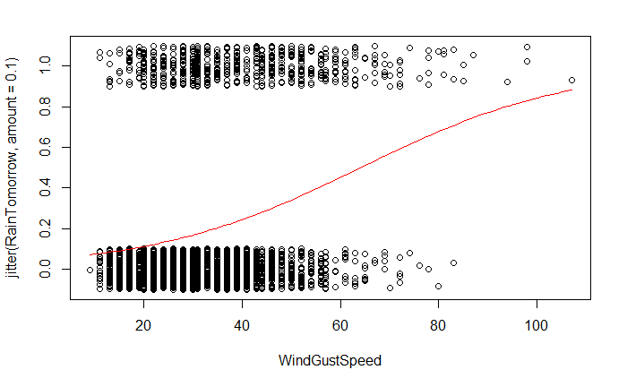

```r
B0 = summary(mod1)$coef[1]
B1 = summary(mod1)$coef[2]
#We get the coefficients above.
#We plot the curve using the coefficients gathered above.
plot(jitter(RainTomorrow, amount=.1)~WindGustSpeed, data=final)
curve(exp(B0+B1*x)/(1+exp(B0+B1*x)), add=TRUE, col="red")
```

```r
#We calculate the confidence interval for the odds of rain tomorow. Essentially we can predict at a 95% level of confidence the rain to increase by a factor of 1.0409 and 1.05510.
exp(confint(mod1, level=.95))
```

```
                   2.5 %     97.5 %
(Intercept)   0.03781822 0.06440846
WindGustSpeed 1.04098599 1.05510739
```

```r
#For each 1mph increase in Wind gust speed, the odds that it will rain that day change by 1.0409 and 1.055 at a confidence level of 95%. Since the values are above one, it is saying that the change of the rain increases slightly based on a 1 magnitude increase in WindGustSpeed.
```

```r
#We calculate the G statistic by subtracting the residual deviance from the null deviance.
#Notice that the residual deviance is less than the null deviance, suggesting that there is an improvement in -2log(L) over just a mode with a constant term.
#The null hypothesis in this test for overall-fit is that the coefficients of the predictors (B1=B2=Bk=0) while the alternate hypothesis states that there exists a coefficient in this model that does not equal to 0.
#We calculate the G-statistic (199.5) and calculate the p-value using a chi-squared test.
#p-value is equal to 0, so we reject the null hypothesis, there exists a coefficient that does not equal to 0, suggesting that the model's predictor (WindGustSpeed) has a relationship to rainfall. And the relationship to Rainfall is also significant as the chi-squared test gave us a value of 0.
G = 3019.4 - 2819.9
print(G)
```

```
[1] 199.5
```

```r
1 - pchisq(G, 1)
```

```
[1] 0
```

```r
#In mod2 I choose the Temp9am predictor. Below is the summary of the model.
#As for individual t-tests, the null hypothesis is that the coefficient is equal to 0 (no relationship for the predictor), while the alternate hypothesis is that the coefficient is not equal to 0 (suggesting a relationship for the predictor). We can see that the predictor Temp9am's p-value is .0566. Thus we fail to reject the  null hypothesis. We do not have strong enough evidence to suggest a correlation between Rainfall and Temperature at 9am.
mod2 = glm(RainTomorrow ~ Temp9am, family=binomial, data=final)
summary(mod2)
```

```
Call:
glm(formula = RainTomorrow ~ Temp9am, family = binomial, data = final)

Deviance Residuals:
    Min       1Q   Median       3Q      Max
-0.7365  -0.6929  -0.6664  -0.6355   1.8990

Coefficients:
             Estimate Std. Error z value Pr(>|z|)
(Intercept) -1.162203   0.110233 -10.543   <2e-16 ***
Temp9am     -0.013673   0.007172  -1.907   0.0566 .
---
Signif. codes:  0 ‘***’ 0.001 ‘**’ 0.01 ‘*’ 0.05 ‘.’ 0.1 ‘ ’ 1

(Dispersion parameter for binomial family taken to be 1)

    Null deviance: 3019.4  on 2976  degrees of freedom
Residual deviance: 3015.8  on 2975  degrees of freedom
AIC: 3019.8

Number of Fisher Scoring iterations: 4
```

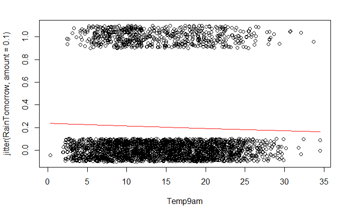

```r
B0 = summary(mod2)$coef[1]
B1 = summary(mod2)$coef[2]
#We get the coefficients from the model.
#We plot said coefficients. We can see in the mode that the relationship between RainTomorrow and Temp9am is not logistic.
plot(jitter(RainTomorrow, amount=.1)~Temp9am, data=final)
curve(exp(B0+B1*x)/(1+exp(B0+B1*x)), add=TRUE, col="red")
```

```r
#Here we calculate the confidence intervals of the odds ratio. Essentially we can predict at a 95% level of confidence as temperature goes up by one, there's a slight chance that the Rainfall could go down and a slight chance the rainfall could go up. It is unclear because at the 2.5% level we see a .9726 factor, meaning that the rainfall will decrease since the value is less than one. However at a 97.5% level we see a factor of 1.0003441, suggesting that there is a slight chance that the rainfall could increase. However, one thing is for sure, at a 95% level of confidence we can say that as Temp9am increases by a magnitude of 1, we can see a decrease in rainfall, with some cases of imperceptible increases. Taking a look at the plot above also confirms as the temperature is increasing the Rainfall seems to be decreasing.
exp(confint(mod2, level=.95))
```

```
                2.5 %    97.5 %
(Intercept) 0.2516131 0.3876611
Temp9am     0.9726035 1.0003441
```

```r
exp(confint(mod2, level=.90))
```

```
                  5 %      95 %
(Intercept) 0.2606323 0.3745871
Temp9am     0.9748186 0.9980970
```

```r
#as we lower the confidence interval, we see that a 90% level of confidence the rainfall is likely to decrease slighly as temperature increases.
```

```r
#We calculate the G statistic by subtracting the residual deviance from the null deviance.
#Notice that the residual deviance is less than the null deviance but only very so slightly, suggesting that there is almost no improvement in -2log(L) over just a model with a constant term.
#The null hypothesis in this test for overall-fit is that the coefficients of the predictors (B1=B2=Bk=0), while the alternate hypothesis states that there exists a coefficient in this model that does not equal to 0.
#We calculate the G-statistic (3.6), which is very small, suggesting no signficant improvement from a constant term model to a predictor based model. We calculate the p-value using a chi-squared test.
#p-value is equal to .05777957, so we fail reject the null hypothesis. Suggesting that there does not exist a coefficient that is not equal to 0. Thus the model itself is no improvement over a model with just a constant variable (no predictor). Thus the predictor Temp9am is not much of an improvement over a model with no predictor and does not serve as a good predictor for predicting Rainfall.
G = 3019.4 -3015.8
print(G)
```

```
[1] 3.6
```

```r
1 - pchisq(G, 1)
```

```
[1] 0.05777957
```

```r
#Let us compare the effectivenss of the two models. The model with WindGustSpeed as the predictor had passed the individual t-test and the chi-squared test.
#However the second mode with Temp9am as the predictor did not pass the individual t-test as it failed to have a p-value less than .05. And it did not pass the chi-squared test as well (p-value is not less than .05). Thus we rejected the predictor Temp9am as a useful one for our model.
#The WindGustSpeed model trumps the Temp9am model.
```

```r
#In model 3 we have included the WindGustSpeed, Humidity9am and Pressure9am in order to construct a logistic model testing whether it will rain or not.
mod3 = glm(RainTomorrow ~ WindGustSpeed + Humidity9am + Pressure9am , family=binomial, data=final)
#As for individual t-tests, the null hypothesis is that the coefficient is equal to 0 (no relationship for the specific predictor), while the alternate hypothesis is that the coefficient is not equal to 0 (suggesting a relationship for the specific predictor). The summary of the model shows us that all of the inidvidual predictors have passed their respective t-tests as all of their p-values are equal to 0.Therefore we have rejected the null-hypothesis and state that all of the predictors in this model show correlation individually.
summary(mod3)
```

```
Call:
glm(formula = RainTomorrow ~ WindGustSpeed + Humidity9am + Pressure9am,
    family = binomial, data = final)

Deviance Residuals:
    Min       1Q   Median       3Q      Max
-2.2498  -0.6090  -0.4018  -0.2283   2.7600

Coefficients:
               Estimate Std. Error z value Pr(>|z|)
(Intercept)   89.984203   9.245324   9.733   <2e-16 ***
WindGustSpeed  0.045310   0.004609   9.831   <2e-16 ***
Humidity9am    0.061774   0.003667  16.846   <2e-16 ***
Pressure9am   -0.096034   0.009066 -10.592   <2e-16 ***
---
Signif. codes:  0 ‘***’ 0.001 ‘**’ 0.01 ‘*’ 0.05 ‘.’ 0.1 ‘ ’ 1

(Dispersion parameter for binomial family taken to be 1)

    Null deviance: 3019.4  on 2976  degrees of freedom
Residual deviance: 2375.2  on 2973  degrees of freedom
AIC: 2383.2

Number of Fisher Scoring iterations: 5
```

```r
#We calculate the G statistic by subtracting the residual deviance from the null deviance.
#Notice that the residual deviance is less than the null deviance, suggesting that there is an improvement in -2log(L) over just a model with a constant term.
#The null hypothesis in this test for overall-fit is that the coefficients (B1=B2=Bk=0) while the alternate hypothesis states that there exists a coefficient in this model that does not equal to 0.
#We calculate the G-statistic (644.2) and calculate the p-value using a chi-squared test.
#p-value is equal to 0, so we reject the null hypothesis, there exists a coefficient that does not equal to 0, suggesting that the the predictors (WindGustSpeed, Humidity9am, Pressure9am) have a relationship with Rainfall.
G = 3019.4 - 2375.2
print(G)
```

```
[1] 644.2
```

```r
1-pchisq(G, 3)
```

```
[1] 0
```

```r
#Compared to the first model with just the WindGustSpeed as a predictor we see that they both pass the t-tests and the chi squared tests, suggesting that the predictors and the model as a whole are appropriate. But, even though they are both good models, multi-variable predictor model has a G-statistic value of 644 while the single predictor has a G-statistic value of 199.5. Because the G-statistic is higher for the multi-variable, suggesting a higher improvement from a constant term model, I will state that the multi-variable model is the better option.
#Compared to the second model, which failed both the predictor test and the whole model test, the multi-predictor model here is clearly the better one. The predictors in this model suggest a relationship while the predictor in mod2 (Temp9am) failed to show a proper logistic correlation.
```

```r
#For mod4 we construct a second order model using the initial predictor variables we used in the single regression models.
mod4 = glm(RainTomorrow ~ WindGustSpeed + Temp9am + I(WindGustSpeed^2) + I(Temp9am^2) + I(WindGustSpeed*Temp9am), family=binomial, data=final)
#As for individual t-tests, the null hypothesis is that the coefficient is equal to 0 (no relationship for the specific predictor), while the alternate hypothesis is that the coefficient is not equal to 0 (suggesting a relationship for the specific predictor). The summary of the model shows us that only some of the inidvidual predictors have passed their respective t-tests. Only WindGustSpeed has passed the t-test as it's p-value is less than .05, suggesting that it has an individual realtionship to Rainfall. The rest of the predictors including interactions between Temp9am and WindGustSpeed do not pass the individual t-tests. The summary also shows the presence of multi-collinearity.
summary(mod4)
```

```
Call:
glm(formula = RainTomorrow ~ WindGustSpeed + Temp9am + I(WindGustSpeed^2) +
    I(Temp9am^2) + I(WindGustSpeed * Temp9am), family = binomial,
    data = final)

Deviance Residuals:
    Min       1Q   Median       3Q      Max
-1.9782  -0.6506  -0.5387  -0.4468   2.3299

Coefficients:
                             Estimate Std. Error z value Pr(>|z|)
(Intercept)                -2.2974314  0.3238124  -7.095 1.29e-12 ***
WindGustSpeed               0.0337820  0.0159504   2.118   0.0342 *
Temp9am                    -0.0271669  0.0360980  -0.753   0.4517
I(WindGustSpeed^2)          0.0003873  0.0002277   1.701   0.0889 .
I(Temp9am^2)               -0.0002949  0.0013019  -0.227   0.8208
I(WindGustSpeed * Temp9am) -0.0006263  0.0007131  -0.878   0.3798
---
Signif. codes:  0 ‘***’ 0.001 ‘**’ 0.01 ‘*’ 0.05 ‘.’ 0.1 ‘ ’ 1

(Dispersion parameter for binomial family taken to be 1)

    Null deviance: 3019.4  on 2976  degrees of freedom
Residual deviance: 2757.7  on 2971  degrees of freedom
AIC: 2769.7

Number of Fisher Scoring iterations: 4
```

```r
#We calculate the G statistic by subtracting the residual deviance from the null deviance.
#Notice that the residual deviance is less than the null deviance, suggesting that there is an improvement in -2log(L) over just a model with just a constant term.
#The null hypothesis in this test for overall-fit is that the coefficients (B1=B2=Bk=0) while the alternate hypothesis states that there exists a coefficient in this model that does not equal to 0.
#We calculate the G-statistic (261.7) and calculate the p-value using a chi-squared test.
#p-value is equal to 0, so we reject the null hypothesis, there exists a coefficient that does not equal to 0. Thus the whole model passes the chi-squared test. However, it is important to note that not all of the predictors are significant and not all of them have a relationship with Rainfall individually. THus we cannot know for certain which predictor has swayed the whole model to be significant.
G = 3019.4 - 2757.7
print(G)
```

```
[1] 261.7
```

```r
1-pchisq(G, 5)
```

```
[1] 0
```

```r
#Compared to the first model with just the WindGustSpeed as a predictor, we see that both models pass the model test however only model 1 passes all of its individual predictor tests. This mode does not pass for the Temp9am predictors and the other Interactions. But, even though they are both good overall models, multi-variable predictor model has a G-statistic value of 261.7 while the single predictor has a G-statistic value of 199.5. Because the G-statistic is higher for the multi-variable, suggesting a higher improvement from a constant term model, I will state that the multi-variable model is the better option. There's a higher drop in deviance on this model compared to the first model.
#Compared to the second model, which failed both the predictor test and the whole model test, the multi-predictor model here is clearly the better one. Temp9am's G-statistic is extremely low at 3.6 while the g-statistic for this model is 261.7. The drop in deviance is higher for this model, suggesting that this model better fits the logistic regression.
```